```python
import pandas as pd
import plotly.express as px

# 2 lines below for html export
import plotly.io as pio
pio.renderers.default ='notebook'

# 2 lines below for PDF export
#!pip install Pyppeteer
#!pyppeteer-install

from IPython.display import YouTubeVideo
```

# Models Vs Reality

```python
YouTubeVideo("W4OczhN3Z7U", height=600, width=1000)
```

[video not shown]

## Introduction

Why Image Processing? Is this not a Computer Vision module?\ While image processing is a large field in its own right it is generally considered to be a task that changes an image in some way for the sake of the human viewer.\ However, in many cases it is also the first stage of computer vision applications.\ It is generally thought of as a pre-processing step which modifies the image in such a way as to make it more suitable for computer analysis.

### Point operators or point processes

The simplest of image processing operators are the point operators. These are operators that manipulate or change each pixel in an image independently of the pixels around it (referred to as neighbours). Examples:\

- Brightness adjustment.
- Contrast adjustment.
- Colour correction.
- Colour transforms.

### Operator

An operator in image processing is a function which takes a pixel value and produces a new pixel value.

$g(\vec{x}) = h(f(\vec{x}))$

Usually for an image (in the continuous domain), $\vec{x} \in \mathbb{R}^2$ if it is a grey scale image and $\vec{x} \in \mathbb{R}^3$ for a colour image.

$\begin{bmatrix} x_1'x_1 & x_1'y_1 & x_1'& y_1'x_1&y_1'y_1&y_1'&x_1&y_1&1\\\ x_2'x_2 & x_2'y_2 & x_2'& y_2'x_2&y_2'y_2&y_2'&x_2&y_2&1\\\ x_3'x_3 & x_3'y_3 & x_3'& y_3'x_3&y_3'y_3&y_3'&x_3&y_3&1\\\ x_4'x_4 & x_4'y_4 & x_4'& y_4'x_4&y_4'y_4&y_4'&x_4&y_4&1\\\ x_5'x_5 & x_5'y_5 & x_5'& y_5'x_5&y_5'y_5&y_5'&x_5&y_5&1\\\ x_6'x_6 & x_6'y_6 & x_6'& y_6'x_6&y_6'y_6&y_6'&x_6&y_6&1\\\ x_7'x_7 & x_7'y_7 & x_7'& y_7'x_7&y_7'y_7&y_7'&x_7&y_7&1\\\ x_8'x_8 & x_8'y_8 & x_8'& y_8'x_8&y_8'y_8&y_8'&x_8&y_8&1\\\ \end{bmatrix} \begin{bmatrix} e_{11}\\\ e_{21}\\\ e_{31}\\\ e_{12}\\\ e_{22}\\\ e_{32}\\\ e_{13}\\\ e_{23}\\\ e_{33} \end{bmatrix} = 0$

[figure not shown]

```python
import matplotlib.pyplot as plt
import numpy as np

from sklearn import datasets, linear_model
from sklearn.metrics import mean_squared_error, r2_score

# Load the diabetes dataset
diabetes_X, diabetes_y = datasets.load_diabetes(return_X_y=True)


print(diabetes_X.shape)

# Use only one feature
diabetes_X = diabetes_X[:, np.newaxis, 2]
print(diabetes_X.shape)
```

```
(442, 10)
(442, 1)
```

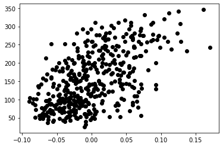

```python
plt.scatter(diabetes_X, diabetes_y, color="black")
```